# Análise de Personalidade de Clientes - Clusters

Gleynner Ghiotto

```r
# Carregar pacotes utilizados nesta etapa:

library(tidyverse)
library(factoextra)
library(reshape2)
```

# Carregar dados

Carregar conjunto de dados trabalhado na etapa de pré-processamento e análise exploratória de dados (EDA).

```r
df_eda <- read.csv("df_eda_marketing_campaign.csv",
                  header = TRUE)
head(df_eda, n=10)
```

|  | ID | Year_Birth | Education | Marital_Status | Income | Kidhome | Teenhome | Dt_Customer | Recency | MntWines | MntFruits | MntMeatProducts | MntFishProducts | MntSweetProducts | MntGoldProds | NumDealsPurchases | NumWebPurchases | NumCatalogPurchases | NumStorePurchases | NumWebVisitsMonth | AcceptedCmp3 | AcceptedCmp4 | AcceptedCmp5 | AcceptedCmp1 | AcceptedCmp2 | Complain | Response | Idade | Education_dummy | … |
| --- | --- | --- | --- | --- | --- | --- | --- | --- | --- | --- | --- | --- | --- | --- | --- | --- | --- | --- | --- | --- | --- | --- | --- | --- | --- | --- | --- | --- | --- | --- |
| 1 | 5524 | 1957 | Postgraduate | Alone | 58138 | 0 | 0 | 2012-09-04 | 58 | 635 | 88 | 546 | 172 | 88 | 88 | 3 | 8 | 10 | 4 | 7 | 0 | 0 | 0 | 0 | 0 | 0 | 1 | 67 | 1 | … |
| 2 | 2174 | 1954 | Postgraduate | Alone | 46344 | 1 | 1 | 2014-03-08 | 38 | 11 | 1 | 6 | 2 | 1 | 6 | 2 | 1 | 1 | 2 | 5 | 0 | 0 | 0 | 0 | 0 | 0 | 0 | 70 | 1 | … |
| 3 | 4141 | 1965 | Postgraduate | In couple | 71613 | 0 | 0 | 2013-08-21 | 26 | 426 | 49 | 127 | 111 | 21 | 42 | 1 | 8 | 2 | 10 | 4 | 0 | 0 | 0 | 0 | 0 | 0 | 0 | 59 | 1 | … |
| 4 | 6182 | 1984 | Postgraduate | In couple | 26646 | 1 | 0 | 2014-02-10 | 26 | 11 | 4 | 20 | 10 | 3 | 5 | 2 | 2 | 0 | 4 | 6 | 0 | 0 | 0 | 0 | 0 | 0 | 0 | 40 | 1 | … |
| 5 | 5324 | 1981 | Postgraduate | In couple | 58293 | 1 | 0 | 2014-01-19 | 94 | 173 | 43 | 118 | 46 | 27 | 15 | 5 | 5 | 3 | 6 | 5 | 0 | 0 | 0 | 0 | 0 | 0 | 0 | 43 | 1 | … |
| 6 | 7446 | 1967 | Postgraduate | In couple | 62513 | 0 | 1 | 2013-09-09 | 16 | 520 | 42 | 98 | 0 | 42 | 14 | 2 | 6 | 4 | 10 | 6 | 0 | 0 | 0 | 0 | 0 | 0 | 0 | 57 | 1 | … |
| 7 | 965 | 1971 | Postgraduate | Alone | 55635 | 0 | 1 | 2012-11-13 | 34 | 235 | 65 | 164 | 50 | 49 | 27 | 4 | 7 | 3 | 7 | 6 | 0 | 0 | 0 | 0 | 0 | 0 | 0 | 53 | 1 | … |
| 8 | 6177 | 1985 | Postgraduate | In couple | 33454 | 1 | 0 | 2013-05-08 | 32 | 76 | 10 | 56 | 3 | 1 | 23 | 2 | 4 | 0 | 4 | 8 | 0 | 0 | 0 | 0 | 0 | 0 | 0 | 39 | 1 | … |
| 9 | 4855 | 1974 | Postgraduate | In couple | 30351 | 1 | 0 | 2013-06-06 | 19 | 14 | 0 | 24 | 3 | 3 | 2 | 1 | 3 | 0 | 2 | 9 | 0 | 0 | 0 | 0 | 0 | 0 | 1 | 50 | 1 | … |
| 10 | 5899 | 1950 | Postgraduate | In couple | 5648 | 1 | 1 | 2014-03-13 | 68 | 28 | 0 | 6 | 1 | 1 | 13 | 1 | 1 | 0 | 0 | 20 | 1 | 0 | 0 | 0 | 0 | 0 | 0 | 74 | 1 | … |

# Gerar clusters

A ideia principal da Análise de Cluster é a possibilidade de classificar os objetos em grupos, de forma que, dentro de um mesmo grupo, os objetos sejam o mais similares possível e, de forma análoga, que os diversos grupos (clusters) sejam o mais diferente possível em sua constituição. Como este tipo de aprendizado é não supervisionado, os dados não possuem rótulos e o algoritmo aprende as relações entre eles.

O algoritmo K-means começa com a inicialização aleatória de k centroides. Para cada ponto do conjunto de dados, calcula-se a distância até os centroides e os pontos são atribuídos ao cluster cujo centroide está mais próximo dele. Após essa atribuição, a posição de cada centroide é recalculada por meio da média dos pontos pertencentes de cada cluster. O processo de atribuição de pontos e o recalculo dos centroides é repetido até que as posições dos centroides se estabilizem, ou seja, não ocorram mudanças significativas.

```r
nomes <- c("Income","Kidhome","MntFruits","MntMeatProducts","MntFishProducts","MntSweetProducts",
           "NumWebPurchases","NumCatalogPurchases","NumStorePurchases","NumWebVisitsMonth","Idade",
           "N_Children","Gasto_total","Numero_compras","Valor_medio_de_compra","Class_VMC")

df_cluster <- df_eda[,nomes[-16]]

X1 <- df_cluster %>% scale()
```

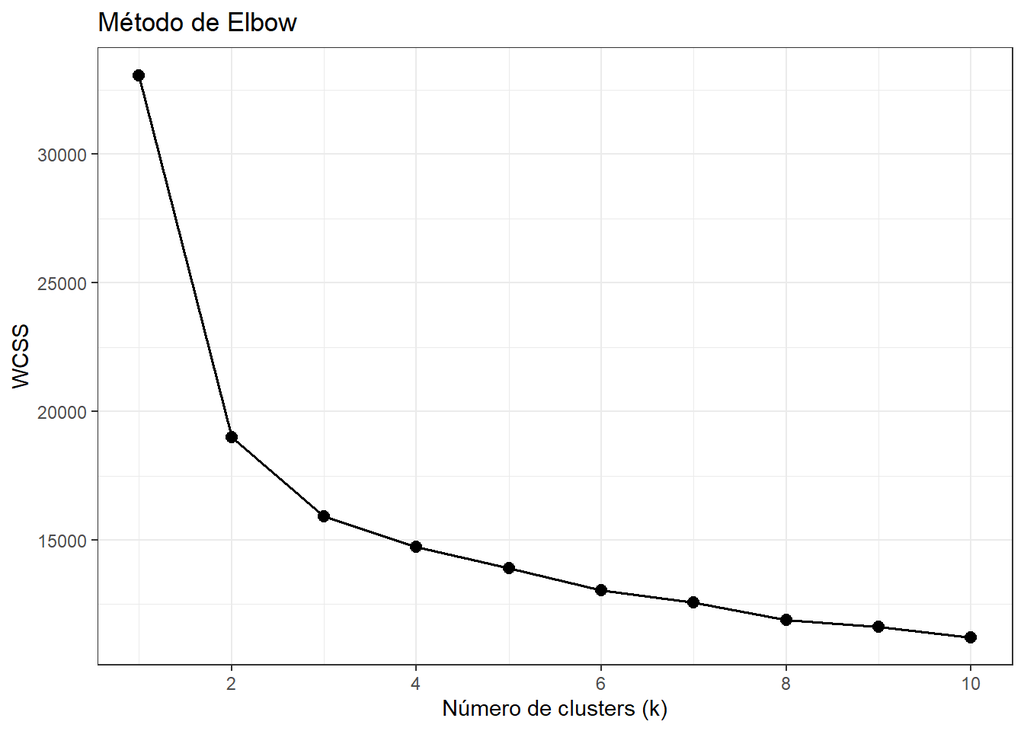

```r
set.seed(1)
wcss = vector()
for (i in 1:10) {
  kmeans = kmeans(x = X1, centers = i)
  wcss[i] = sum(kmeans$withinss)
}

ggplot(data = data.frame(n = c(1:10),WCSS = wcss),aes(x = n, y=WCSS)) +
  geom_line(linewidth=0.7,linetype = 1,lineend  = "round",linejoin = "round",linemitre=1) +
  geom_point(size = 2.5) +
  labs(x="Número de clusters (k)",y="WCSS", title="Método de Elbow") +
  scale_x_continuous(breaks = seq(0,10,2)) +
  theme_bw()
```

O método de Elbow, também conhecido como método do cotovelo, é um gráfico onde eixo x representa o número de clusters (k) e o eixo y representa a soma dos quadrados das distâncias de cada ponto ao centroide de seu respectivo cluster (WCSS, Within-Cluster Sum of Squares). O objetivo é encontrar um ponto no gráfico onde a diminuição da soma do WCSS se torna menos acentuada, formando um “cotovelo”. Esse ponto indica um bom número de clusters, pois é onde adicionar mais clusters não traz uma redução significativa da compacidade dos clusters.

Para o exemplo em questão, utilizaremos 3 clusters, pois, a partir desse ponto, a redução do WCSS em função do número de clusters torna-se menos acentuada.

```r
set.seed(1)
kmeans = kmeans(x = X1, centers = 3)
previsoes = kmeans$cluster

X1 <- as.data.frame(X1)
```

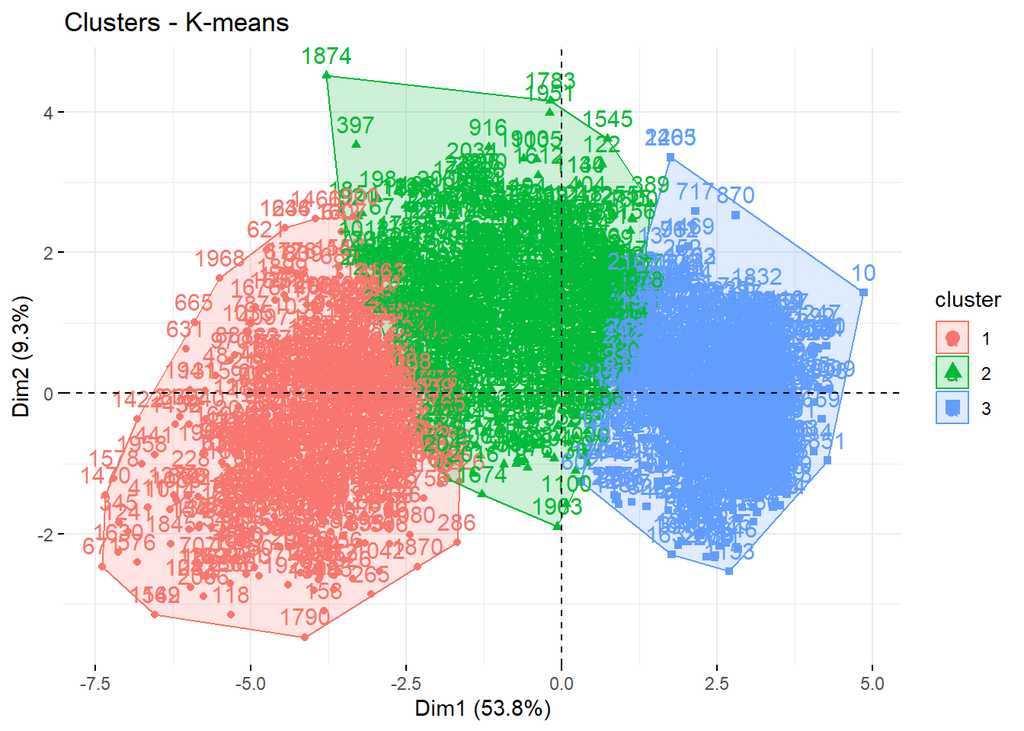

```r
fviz_cluster(kmeans, X1,
             main = "Clusters - K-means",
             ggtheme = theme_minimal()) +
  geom_hline(aes(yintercept =0), linetype = 2) +
  geom_vline(aes(xintercept =0), linetype = 2)
```

```r
data.frame(Cluster = previsoes,
           Valor_medio_de_compra = df_cluster$Valor_medio_de_compra,
           df_cluster %>% select(-"Valor_medio_de_compra"),
           check.names = F) %>% dplyr::group_by(Cluster) %>%
  dplyr::summarise_all(list(mean)) %>% t() %>% as.data.frame() %>%
  .[-1,] %>% round_df(2)
```

|  | V1 | V2 | V3 |
| --- | --- | --- | --- |
| Valor_medio_de_compra | 75.60 | 42.09 | 14.94 |
| Income | 76649.76 | 58868.79 | 34845.03 |
| Kidhome | 0.03 | 0.17 | 0.82 |
| MntFruits | 70.98 | 23.61 | 4.87 |
| MntMeatProducts | 478.07 | 136.89 | 24.30 |
| MntFishProducts | 104.07 | 31.94 | 6.73 |
| MntSweetProducts | 73.61 | 23.98 | 4.81 |
| NumWebPurchases | 5.16 | 6.27 | 2.22 |
| NumCatalogPurchases | 6.19 | 3.15 | 0.56 |
| NumStorePurchases | 8.35 | 7.87 | 3.25 |

[output cut: 5 more lines]

Por meio dos clusters formados, o grupo de número 1 é composto pelos clientes com o maior valor médio de compra, isto é, o grupo em que o gasto total dividido pelo número de compras é maior. Nesse grupo, os clientes têm maior renda média anual e tendem a possuir menor número de filhos. Nota-se também que este perfil de clientes possui maiores gastos com frutas, produtos cárneos, pesqueiros e doces. Ainda, eles têm preferência por realizar suas compras por meio da loja física e catálogo, sendo o tipo de pessoas que menos visita o site da empresa.

O grupo 2 possui um perfil intermediário, possuindo nível de compra não tão alto quanto o grupo 1 e nem tão baixo quanto o grupo 3. Esse perfil de clientes são os que mais utilizam o web site da empresa para fazer suas compras. Já o grupo 3 possui um perfil mais conservador, sendo formado pelos clientes que possuem maior número de crianças em casa e é o grupo que mais visitou o web site da empresa no último mês (possivelmente em busca de promoções).

Abaixo segue uma representação da tabela acima, represantada por seus valores em escala, onde: os valores positivos represantam gastos acima da média; valores negativos representam gastos abaixo da média; e, valores iguais a zero, gastos iguais ao valor médio.

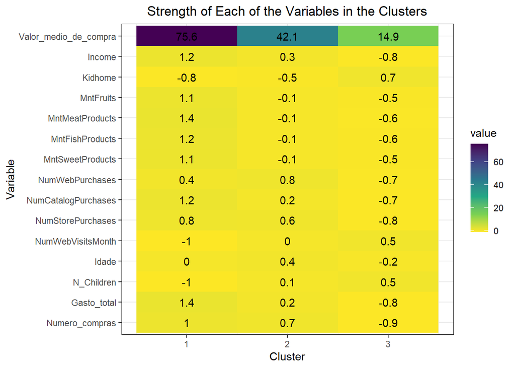

```r
cluster_summary <- data.frame(Cluster = previsoes,
                        rev(X1) %>% select(-"Valor_medio_de_compra"),
                        Valor_medio_de_compra = df_cluster$Valor_medio_de_compra,
                        check.names = F) %>% dplyr::group_by(Cluster) %>%
  dplyr::summarise_all(list(mean))
melt_cluster_summary <- melt(as.matrix(cluster_summary[,-1]))

ggplot(melt_cluster_summary, aes(Var2, Var1)) +
  scale_fill_continuous(type = "viridis", direction = -1) +
  geom_tile(aes(fill = value)) +
  geom_text(aes(label = round(value, 1))) +
  theme_bw() +
  ggtitle("Strength of Each of the Variables in the Clusters") +
  theme(plot.title = element_text(hjust = 0.5)) +
  labs(x="Variable", y="Cluster") +
  coord_flip()
```